# Data 605 Homework Week-7

## —————————————————————————

### **Student Name :** Sachid Deshmukh

### **Date :** 03/14/2019

- > [GitHub Location for rmd file](https://github.com/mlforsachid/MSDSQ2Data605/blob/master/Week7/HW-7/SachidVijay.Deshmukh60.Rmd)
- > [RPubs location of published file](http://rpubs.com/sachid/Data605Week7HW)

## —————————————————————————

**1. Let X1,X2,…,Xn be n mutually independent random variables, each of which is uniformly distributed on the integers from 1 to k. Let Y denote the minimum of the Xi’s. Find the distribution of Y.**

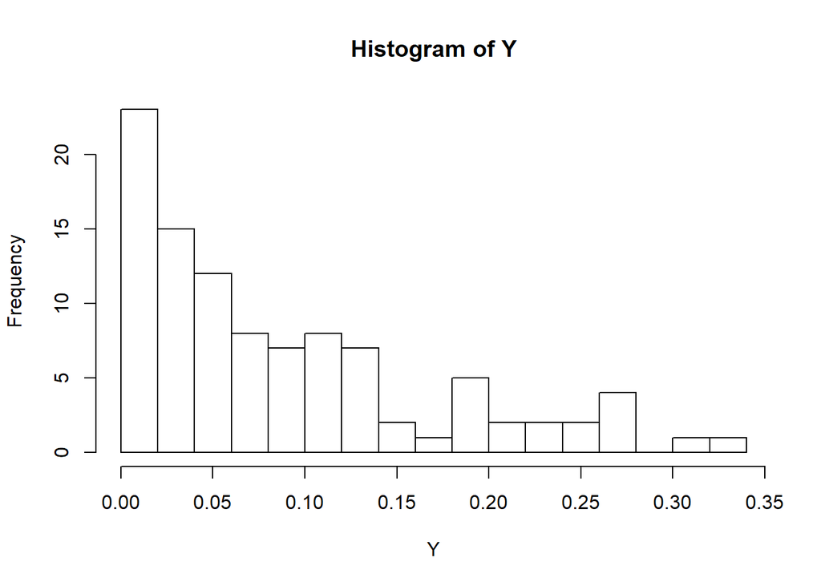

```r
sim.uni <- function(a,b) {
  Y = c()
  for (i in 1:b){
    X <- runif(a)
    Y[i] = min(X)
  }
  return(Y)
}

Y <- sim.uni(10, 100)

hist(Y,  breaks = 20)
```

**2. Your organization owns a copier (future lawyers, etc.) or MRI (future doctors). This machine has a manufacturer’s expected lifetime of 10 years. This means that we expect one failure every ten years. (Include the probability statements and R Code for each part.).**

**a) What is the probability that the machine will fail after 8 years?. Provide also the expected value and standard deviation. Model as a geometric. (Hint: the probability is equivalent to not failing during the first 8 years..)**

```r
p=0.1
pgeom(8, p, lower.tail = FALSE)
```

```
## [1] 0.3874205
```

```r
mean = 1/p
sd = sqrt(((1-p)/p^2))
print(mean)
```

```
## [1] 10
```

```r
print(sd)
```

```
## [1] 9.486833
```

**b) What is the probability that the machine will fail after 8 years?. Provide also the expected value and standard deviation. Model as an exponential.**

```r
pexp(8, p, lower.tail = FALSE)
```

```
## [1] 0.449329
```

```r
mean = p^-1
sd = sqrt(p^-2)
print(mean)
```

```
## [1] 10
```

```r
print(sd)
```

```
## [1] 10
```

**c) What is the probability that the machine will fail after 8 years?. Provide also the expected value and standard deviation. Model as a binomial. (Hint: 0 success in 8 years)**

```r
pbinom(0, 8, 0.1)
```

```
## [1] 0.4304672
```

```r
mean = 10* 0.1
sd = sqrt(10*p*(1-p))
print(mean)
```

```
## [1] 1
```

```r
print(sd)
```

```
## [1] 0.9486833
```

**d)What is the probability that the machine will fail after 8 years?. Provide also the expected value and standard deviation. Model as a Poisson.**

```r
ppois(0, 8/10)
```

```
## [1] 0.449329
```

```r
mean = .1
sd = sqrt(mean)
print(mean)
```

```
## [1] 0.1
```

```r
print(sd)
```

```
## [1] 0.3162278
```